# 金融知识图谱

### 三元组抽取以及框架设计额。

理论上，创建一个优秀的知识图谱，第一步应该是在专业的知识背景下做实体抽取和属性抽取（正常的三元组框架由一下两种：1. 实体-关系-实体 2.实体-属性-属性值），确定我们想通过知识图谱做解决怎样的问题。对一单一文章来说，定义框架相对困难，但是通过熟练阅读https://seekingalpha.com/article/4618324-top-airline-stocks-buy-2023，我猜测我们的目的是分析这三只股票与其他的实体之间的关系，以及三只股票具有什么样的属性，导致了它成为被强烈推荐的股票。在这个框架下我将尝试两种方式进行实体抽取：

1.创建以三个股票为基础的pipeline寻找三元组的代码

2.通过chatgpt阅读文章直接提取所需的三元组

## 1.创建以三个股票为基础的pipeline寻找三元组的代码

```python
from docx import Document

def read_word_file(filename):
    doc = Document(filename)
    result = []
    for paragraph in doc.paragraphs:
        result.append(paragraph.text)
    return "\n".join(result)

filename = 'Top Airline Stocks To Buy In 2023-preprocessing.docx' # 你的Word文档的文件名
news=read_word_file(filename)
print(news)
```

```
Top Airline Stocks To Buy In 2023 Summary • "United Airlines" and "Delta Air Lines" have posted record earnings, beating analysts' expectations. "American Airlines Group Inc." is anticipated to follow suit. • Demand for air travel is increasing. This earnings season witnessed top-performing airline …
Top U.S. Airline Stocks Take Flight "United Airlines" (NASDAQ:UAL) posted record earnings yesterday, with revenues exceeding analysts' expectations. "United Airlines" followed the same trend as "Delta Air Lines" (NYSE:DAL), whose Q2 earnings beat both top and bottom line results. "United Airlines" a…
Although the cyclical business faltered during COVID and over the winter holidays with cancellations and passenger dissatisfaction, airlines are experiencing a turnaround in 2023, reaching record levels over the 4th of July. As people return to airlines, "United Airlines" and "Delta Air Lines", two …
Domestic Market Share of U.S. Airlines (Feb 2022 to Jan 2023): The description provides the market share of various U.S. airlines in the domestic sector from February 2022 to January 2023. Major players in the sector include "United Airlines" with a market share of 15.6%, "Southwest Airlines" at 16.…
Four airlines dominate domestic market share, but only "Delta Air Lines", "United Airlines", and "American Airlines Group Inc." possess the most robust quant-rated fundamentals. "Delta Air Lines" has advanced +49% over the last year. "United Airlines" is up 32%. "American Airlines Group Inc." is up …
With these changes, your text is now easier to process for triple extraction, and any ambiguities related to entities have been resolved.
1. Delta Air Lines, Inc.
As of 7/19/23, Delta Air Lines, Inc. has a Market Capitalization of $30.97B.
Delta Air Lines, Inc. holds a Quant Rating of Strong Buy.
As of 7/19/23, Delta Air Lines, Inc. ranks 12 out of 654 in the Quant Sector.
As of 7/19/23, Delta Air Lines, Inc. ranks 3 out of 27 in the Quant Industry.
Delta Air Lines, Inc., the premier passenger airlines carrier, offers air transport for both passengers and cargo. It is a top-ranked U.S. carrier and favored by Morgan Stanley.
Delta Air Lines, Inc. offers elite experiences, including advanced technologies, amenities, and personalized experiences. It is among the top-rated airlines according to Forbes, Fortune, and the Wall Street Journal.
On July 13th, Delta Air Lines, Inc. reported second-quarter earnings that capitalized on its new fleet, increasing the overall capacity by 7%.
In Q2, Delta Air Lines, Inc. reported an EPS of $2.68, beating the estimate by $0.28, and a revenue of $15.58B, beating the estimate by nearly 13%.
Delta Air Lines, Inc.'s premium experiences, which attract and reward brand-loyal frequent flyers, are reflected in Delta's per-unit revenue premiums compared to its competitors.
Delta Air Lines, Inc. has a price-competitive ability and offerings, including a five-cabin segmentation strategy, which led to an industry-leading $0.0409 spread between passenger revenue and costs per mile from 2015 through 2019.
With one of the most extensive frequent flyer programs in the U.S., Delta Air Lines, Inc. generates high-margin revenue streams from banks and credit card rewards.
In the last 90 days, Delta Air Lines, Inc. had nineteen upward estimate revisions by Wall Street analysts with zero downward revisions.
Delta Air Lines, Inc.'s average booking capacity was 85.4% over the five years before the pandemic, topping 88% in average bookings for Q2.
Delta Air Lines, Inc. has strong growth metrics, including an EPS FWD (3-5 year CAGR) of 33.51%, year-over-year forward EBITDA growth of over 700% compared to the sector, and industry-leading profitability in 2022, allowing it to pay more than $550M in profit sharing.
Delta Air Lines, Inc. reported record June quarter revenue of $14.6 billion, a 19% increase over the previous year.
The forward P/E ratio of Delta Air Lines, Inc. is 8.04x, which is more than a 60% discount to the sector median of 20.19x.
Delta Air Lines, Inc. has a forward PEG that is 88% different from the sector.
Delta Air Lines, Inc.'s stock is trading near its 52-week high and its quarterly price performance is rising.
Delta Air Lines, Inc. is considered a strong buy airline and is recommended for inclusion in a portfolio.
2. United Airlines Holdings, Inc.
As of 7/19/23, United Airlines Holdings, Inc. has a Market Capitalization of $17.97B.
United Airlines Holdings, Inc. has a Quant Rating of Strong Buy.
As of 7/19/23, United Airlines Holdings, Inc. is ranked 15 out of 654 in the Quant Sector.
As of 7/19/23, United Airlines Holdings, Inc. ranks 4 out of 27 in the Quant Industry.
United Airlines Holdings, Inc. tagline is "Good leads the way".
United Airlines Holdings, Inc.'s Q2 earnings results exceeded analysts' expectations, resulting in a 2.7% increase in shares on Wednesday.
United Airlines Holdings, Inc. reported a Non-GAAP EPS of $5.03, beating the estimate by $0.98, a revenue of $14.18 billion, beating the estimate by $250M, and a net income of $1.08B compared to the $329M for the same period last year.
A decrease in fuel prices contributed to the improved financial performance of United Airlines Holdings, Inc.
United Airlines Holdings, Inc.'s cost-cutting measures and increased capacity led to stronger profitability.
United Airlines Holdings, Inc.'s successful plane investment strategy has enhanced profitability.
United Airlines Holdings, Inc.'s Factor Grades from Seeking Alpha include a 'B' Revisions grade and A+ Growth and Profitability.
The revenue growth (YoY) for United Airlines Holdings, Inc. is +68%, the forward EPS (3-5Y CAGR) is +59%, and the company has strong operating cash flows plus $7.73B in cash.
According to United Airlines CEO Scott Kirby, the financial performance in Q2 and outlook for the remainder of the year are indicators of the success of the United Next strategy.
```

[output cut: 19 more lines]

```
American Airlines Group Inc. has the youngest fleet among major U.S. carriers, which provides greater efficiency by limiting fuel and maintenance expenses, and also allows the company to expand capacity.
Over the last 90 days, sixteen analysts have revised their estimates upwards for American Airlines Group Inc.
With a year-over-year revenue growth of +50%, strong operating cash flow, and $4.32B in cash, American Airlines Group Inc. is positioned for potential future growth.
Despite the risks associated with the airline industry, American Airlines Group Inc. should be considered as a top stock for an airline portfolio, alongside Delta Air Lines and United Airlines Holdings, Inc.
The airline industry is cyclical and can experience downturns in discretionary spending and leisure travel during economic slowdowns.
Rising costs in an inflationary environment have impacted the industry, despite falling fuel prices.
Since the pandemic, airlines, including American Airlines Group Inc., Delta Air Lines, and United Airlines Holdings, Inc., have been recovering, although overcrowded cabins, labor shortages, and increased costs pose ongoing risks.
Strikes by pilots and airline staff seeking better conditions and pay have affected all three airlines.
Each of my picks, Delta Air Lines, American Airlines Group Inc., and United Airlines Holdings, Inc., has shown fundamental strength, as evidenced by their Quant Ratings and Factor Grades.
Analysts' forward earnings estimates for these airlines are optimistic, having been revised upwards over the last 90 days.
Despite workforce reductions and shortages, these airlines, Delta Air Lines, American Airlines Group Inc., and United Airlines Holdings, Inc., have robust yields amidst robust travel demand and are considered strong buys amongst Top Industrial Stocks.
Delta Air Lines and United Airlines Holdings, Inc. have reported record revenues, and it is anticipated that American Airlines Group Inc. will follow.
All three airlines have demonstrated cost control, strong financials, excellent growth, and are projected to see revenue growth of over +20%.
They also trade at significant discounts, with their forward PEG trading at more than an 85% discount to the sector.
For those interested in Top Rated Stocks, Delta Air Lines, American Airlines Group Inc., and United Airlines Holdings, Inc. are recommended for inclusion in portfolios for 2023.
```

```python
#Import libraries
import pandas as pd
import numpy as np
#visualization
import matplotlib.pyplot as plt
#for text
import wikipediaapi
import nltk
import re
#for nlp
import spacy
from spacy import displacy

nlp = spacy.load("en_core_web_sm")
doc = nlp(u"This is a sentence.")
displacy.render(doc, style='dep', jupyter=True)
import textacy
import networkx as nx
import dateparser
```

[output not shown]

[figure not shown]

```python
nlp = spacy.load("en_core_web_sm")
doc = nlp(news)
```

## 自然语言处理

此类任务的库是SpaCy，它是一种开源软件，用于高级自然语言处理，利用Cython（C+Python）进行加速。SpaCy使用预训练的语言模型对文本进行标记化，并将其转换为“文档”对象，该对象包含模型预测的所有注释。

NLP模型的第一个输出是句子分割(中文有自己的分词规则)：即确定句子的起始和结束位置的问题。

```python
# from text to a list of sentences
lst_docs = [sent for sent in doc.sents]
print("tot sentences:", len(lst_docs))
```

```
tot sentences: 92
```

```python
lst_docs[1]
```

```
"American Airlines Group Inc." is anticipated to follow suit.
```

```python
for token in lst_docs[20]:
    print (token.text,'-->','pos: '+token.pos_,'|','dep: '+token.dep_, '')
```

```
" --> pos: PUNCT | dep: punct
Delta --> pos: PROPN | dep: compound
Air --> pos: PROPN | dep: compound
Lines --> pos: PROPN | dep: nsubj
" --> pos: PUNCT | dep: punct
has --> pos: AUX | dep: aux
advanced --> pos: VERB | dep: ROOT
+49 --> pos: PROPN | dep: compound
% --> pos: NOUN | dep: dobj
over --> pos: ADP | dep: prep
the --> pos: DET | dep: det
last --> pos: ADJ | dep: amod
year --> pos: NOUN | dep: pobj
. --> pos: PUNCT | dep: punct
```

```python
from spacy import displacy

displacy.render(lst_docs[1], style="dep", options={"distance":100})
```

[figure not shown]

### NER

```python
for tag in lst_docs[1].ents:
    print(tag.text, f"({tag.label_})")
```

```
American Airlines Group Inc. (ORG)
```

```python
#使用SpaCY的图形工具显示：
displacy.render(lst_docs[10],style='ent')
```

" United Airlines ORG " followed the same trend as "Delta Air Lines" ( NYSE ORG :DAL), whose Q2 CARDINAL earnings beat both top and bottom line results.

```python
#返回实体和实体之间的关系
def extract_entities_relations(doc, nlp):
    a, b, prev_dep, prev_txt, prefix, modifier = "", "", "", "", "", ""
    relation = ""
    matcher = spacy.matcher.Matcher(nlp.vocab)
    p1 = [{'DEP':'ROOT'},
          {'DEP':'prep', 'OP':"?"},
          {'DEP':'agent', 'OP':"?"},
          {'POS':'ADJ', 'OP':"?"}]
    matcher.add(key="matching_1", patterns=[p1])

    for token in doc:
        if token.dep_ != "punct":
            if token.dep_ == "compound":
                prefix = prev_txt +" "+ token.text if prev_dep == "compound" else token.text
            if token.dep_.endswith("mod") == True:
                modifier = prev_txt +" "+ token.text if prev_dep == "compound" else token.text
            if token.dep_.find("subj") == True:
                a = modifier +" "+ prefix + " "+ token.text
                prefix, modifier, prev_dep, prev_txt = "", "", "", ""
            if token.dep_.find("obj") == True:
                b = modifier +" "+ prefix +" "+ token.text
            prev_dep, prev_txt = token.dep_, token.text
    matches = matcher(doc)
    if len(matches) != 0: # make sure there's at least one match
        k = len(matches) - 1
        span = doc[matches[k][1]:matches[k][2]]
        relation = span.text
    a = " ".join([i for i in a.split()])
    b = " ".join([i for i in b.split()])
    return (a.strip(), relation.strip(),b.strip())
```

```python
# 测试在我们的数据集上：
lst_ent=[extract_entities_relations(i,nlp) for i in lst_docs]

lst_ent[10]
```

```
('same Q2 earnings', 'followed', 'bottom results')
```

使用Textacy，这也是SpaCy的一个库

```python
## extract entities and relations
dic = {"id":[], "text":[], "entity":[], "relation":[], "object":[]}

for n,sentence in enumerate(lst_docs):
    lst_generators = list(textacy.extract.subject_verb_object_triples(sentence))
    for sent in lst_generators:
        subj = "_".join(map(str, sent.subject))
        obj  = "_".join(map(str, sent.object))
        relation = "_".join(map(str, sent.verb))
        dic["id"].append(n)
        dic["text"].append(sentence.text)
        dic["entity"].append(subj)
        dic["object"].append(obj)
        dic["relation"].append(relation)


## create dataframe
dtf = pd.DataFrame(dic)

## example
dtf[dtf["id"]==10]
```

|  | id | text | entity | relation | object |
| --- | --- | --- | --- | --- | --- |
| 6 | 10 | "United Airlines" followed the same trend as "... | United_Airlines | followed | trend |
| 7 | 10 | "United Airlines" followed the same trend as "... | Q2_earnings | beat | results |

```python
## extract attributes
attribute = "DATE"
dic = {"id":[], "text":[], attribute:[]}

for n,sentence in enumerate(lst_docs):
    lst = list(textacy.extract.entities(sentence, include_types={attribute}))
    if len(lst) > 0:
        for attr in lst:
            dic["id"].append(n)
            dic["text"].append(sentence.text)
            dic[attribute].append(str(attr))
    else:
        dic["id"].append(n)
        dic["text"].append(sentence.text)
        dic[attribute].append(np.nan)

dtf_att = pd.DataFrame(dic)
dtf_att = dtf_att[~dtf_att[attribute].isna()]

## example
dtf_att[dtf_att["id"]==11]
```

|  | id | text | DATE |
| --- | --- | --- | --- |
| 11 | 11 | "United Airlines" and "Delta Air Lines", two o... | recent quarter |

使用NER（日期）提取属性：

```python
## extract attributes
attribute = "DATE"
dic = {"id":[], "text":[], attribute:[]}

for n,sentence in enumerate(lst_docs):
    lst = list(textacy.extract.entities(sentence, include_types={attribute}))
    if len(lst) > 0:
        for attr in lst:
            dic["id"].append(n)
            dic["text"].append(sentence.text)
            dic[attribute].append(str(attr))
    else:
        dic["id"].append(n)
        dic["text"].append(sentence.text)
        dic[attribute].append(np.nan)

dtf_att = pd.DataFrame(dic)
dtf_att = dtf_att[~dtf_att[attribute].isna()]

## example
dtf_att[dtf_att["id"]==9]
```

|  | id | text | DATE |
| --- | --- | --- | --- |
| 9 | 9 | Top U.S. Airline Stocks Take Flight "United Ai... | yesterday |

```python
## extract attributes
attributes = {"DATE", "PERCENT", "MONEY", "QUANTITY"}  # 指定你想要提取的属性
dic = {"id":[], "text":[], "entity": [], "entity_type": []}

for attr in attributes:
    dic[attr] = []

for n, sentence in enumerate(lst_docs):
    for ent in sentence.ents:
        dic["id"].append(n)
        dic["text"].append(sentence.text)
        dic["entity"].append(ent.text)
        dic["entity_type"].append(ent.label_)

        for attr in attributes:
            if ent.label_ == attr:
                dic[attr].append(ent.text)
            else:
                dic[attr].append(np.nan)

dtf_att = pd.DataFrame(dic)

## example
dtf_att[dtf_att["id"]==3]
```

|  | id | text | entity | entity_type | PERCENT | MONEY | QUANTITY | DATE |
| --- | --- | --- | --- | --- | --- | --- | --- | --- |
| 5 | 3 | This earnings season witnessed top-performing ... | season | DATE | NaN | NaN | NaN | season |

## 网络图

使用网络X库（通常简写为nx）从数据帧创建一个有向图，然后绘制这个图。图中的每个节点代表一个实体，边代表实体之间的关系。图的布局（即节点的位置）是使用spring布局算法计算的，该算法试图将节点位置安排得尽可能均匀，以便将节点间的交叉边最小化。

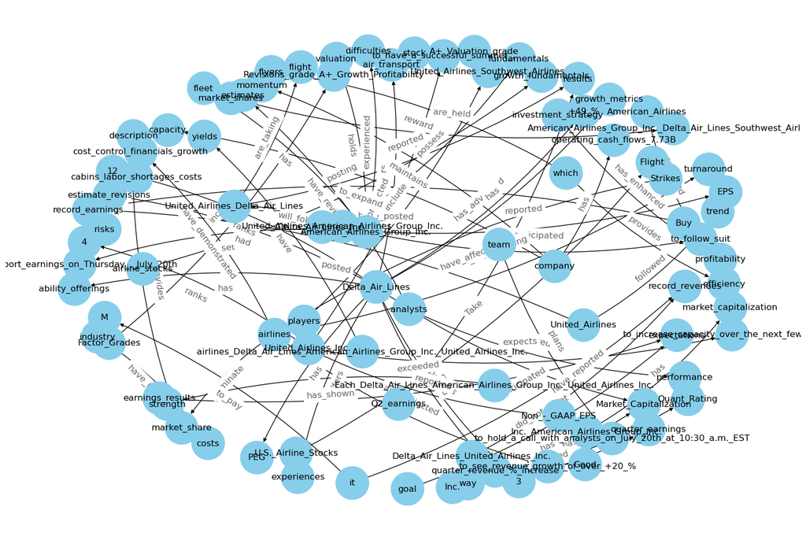

```python
## 创建完整的图形
full_graph = nx.from_pandas_edgelist(dtf, source="entity", target="object",
                            edge_attr="relation",
                            create_using=nx.DiGraph())

## 绘图
plt.figure(figsize=(15,10))

pos = nx.spring_layout(full_graph, k=1)  # 设置布局
node_color = "skyblue"  # 设置节点颜色
edge_color = "black"  # 设置边颜色

# 绘制图形，包括节点和边
nx.draw(full_graph, pos=pos, with_labels=True, node_color=node_color,
        edge_color=edge_color, cmap=plt.cm.Dark2,
        node_size=2000, connectionstyle='arc3,rad=0.1')

# 绘制边的标签（关系）
nx.draw_networkx_edge_labels(full_graph, pos=pos, label_pos=0.5,
                             edge_labels=nx.get_edge_attributes(full_graph,'relation'),
                             font_size=12, font_color='black', alpha=0.6)
plt.show()  # 显示图形
```

[figure not shown]

```python
from mpl_toolkits.mplot3d import Axes3D

fig = plt.figure(figsize=(15,10))
ax = fig.add_subplot(111, projection="3d")
pos = nx.spring_layout(G, k=2.5, dim=3)

nodes = np.array([pos[v] for v in sorted(G) if v!=f])
center_node = np.array([pos[v] for v in sorted(G) if v==f])

edges = np.array([(pos[u],pos[v]) for u,v in G.edges() if v!=f])
center_edges = np.array([(pos[u],pos[v]) for u,v in G.edges() if v==f])

ax.scatter(*nodes.T, s=200, ec="w", c="skyblue", alpha=0.5)
ax.scatter(*center_node.T, s=200, c="red", alpha=0.5)

for link in edges:
    ax.plot(*link.T, color="grey", lw=0.5)
for link in center_edges:
    ax.plot(*link.T, color="red", lw=0.5)

for v in sorted(G):
    ax.text(*pos[v].T, s=v)
for u,v in G.edges():
    attr = nx.get_edge_attributes(G, "relation")[(u,v)]
    ax.text(*((pos[u]+pos[v])/2).T, s=attr)

ax.set(xlabel=None, ylabel=None, zlabel=None,
       xticklabels=[], yticklabels=[], zticklabels=[])
ax.grid(False)
for dim in (ax.xaxis, ax.yaxis, ax.zaxis):
    dim.set_ticks([])
plt.show()
```

```python
dtf['entity'].value_counts().head()
```

```
Delta_Air_Lines                 11
American_Airlines_Group_Inc.     6
airlines                         4
United_Airlines_Inc.             4
Inc.                             4
Name: entity, dtype: int64
```

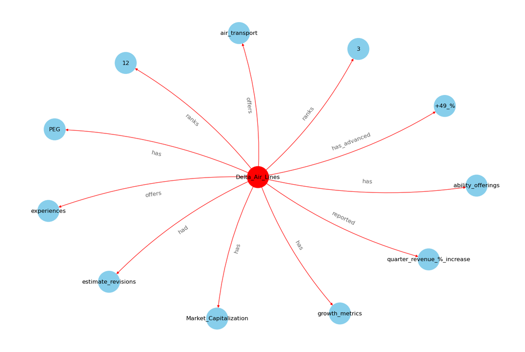

```python
## filter
f = "Delta_Air_Lines"
tmp = dtf[(dtf["entity"]==f) | (dtf["object"]==f)]


## create small graph
G = nx.from_pandas_edgelist(tmp, source="entity", target="object",
                            edge_attr="relation",
                            create_using=nx.DiGraph())


## plot
plt.figure(figsize=(15,10))

pos = nx.nx_agraph.graphviz_layout(G, prog="neato")
node_color = ["red" if node==f else "skyblue" for node in G.nodes]
edge_color = ["red" if edge[0]==f else "black" for edge in G.edges]

nx.draw(G, pos=pos, with_labels=True, node_color=node_color,
        edge_color=edge_color, cmap=plt.cm.Dark2,
        node_size=2000, node_shape="o", connectionstyle='arc3,rad=0.1')

nx.draw_networkx_edge_labels(G, pos=pos, label_pos=0.5,
                        edge_labels=nx.get_edge_attributes(G,'relation'),
                        font_size=12, font_color='black', alpha=0.6)
plt.show()
```

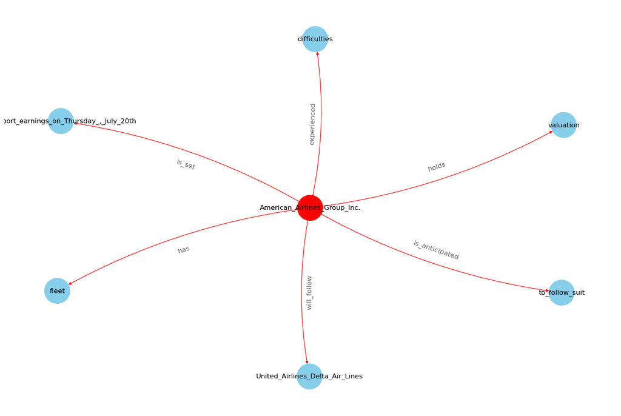

```python
## filter
f = "American_Airlines_Group_Inc."
tmp = dtf[(dtf["entity"]==f) | (dtf["object"]==f)]


## create small graph
G = nx.from_pandas_edgelist(tmp, source="entity", target="object",
                            edge_attr="relation",
                            create_using=nx.DiGraph())


## plot
plt.figure(figsize=(15,10))

pos = nx.nx_agraph.graphviz_layout(G, prog="neato")
node_color = ["red" if node==f else "skyblue" for node in G.nodes]
edge_color = ["red" if edge[0]==f else "black" for edge in G.edges]

nx.draw(G, pos=pos, with_labels=True, node_color=node_color,
        edge_color=edge_color, cmap=plt.cm.Dark2,
        node_size=2000, node_shape="o", connectionstyle='arc3,rad=0.1')

nx.draw_networkx_edge_labels(G, pos=pos, label_pos=0.5,
                        edge_labels=nx.get_edge_attributes(G,'relation'),
                        font_size=12, font_color='black', alpha=0.6)
plt.show()
```

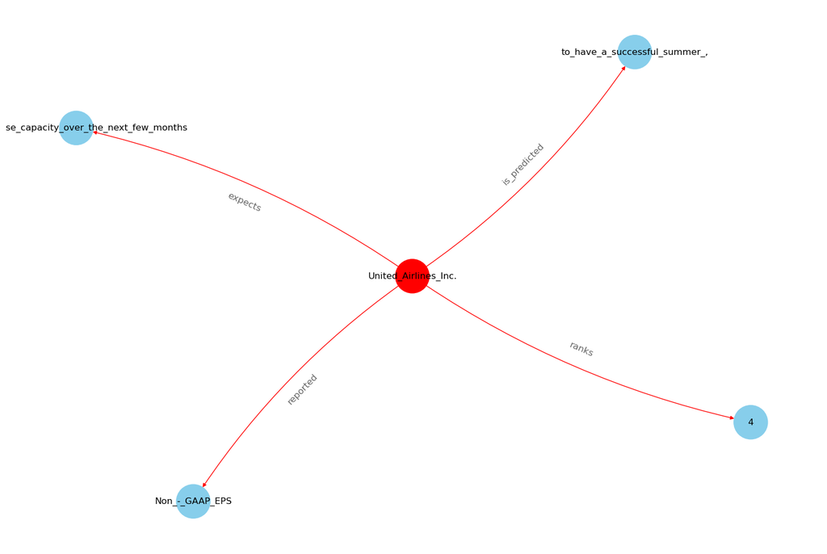

```python
## filter
f = "United_Airlines_Inc."
tmp = dtf[(dtf["entity"]==f) | (dtf["object"]==f)]


## create small graph
G = nx.from_pandas_edgelist(tmp, source="entity", target="object",
                            edge_attr="relation",
                            create_using=nx.DiGraph())


## plot
plt.figure(figsize=(15,10))

pos = nx.nx_agraph.graphviz_layout(G, prog="neato")
node_color = ["red" if node==f else "skyblue" for node in G.nodes]
edge_color = ["red" if edge[0]==f else "black" for edge in G.edges]

nx.draw(G, pos=pos, with_labels=True, node_color=node_color,
        edge_color=edge_color, cmap=plt.cm.Dark2,
        node_size=2000, node_shape="o", connectionstyle='arc3,rad=0.1')

nx.draw_networkx_edge_labels(G, pos=pos, label_pos=0.5,
                        edge_labels=nx.get_edge_attributes(G,'relation'),
                        font_size=12, font_color='black', alpha=0.6)
plt.show()
```

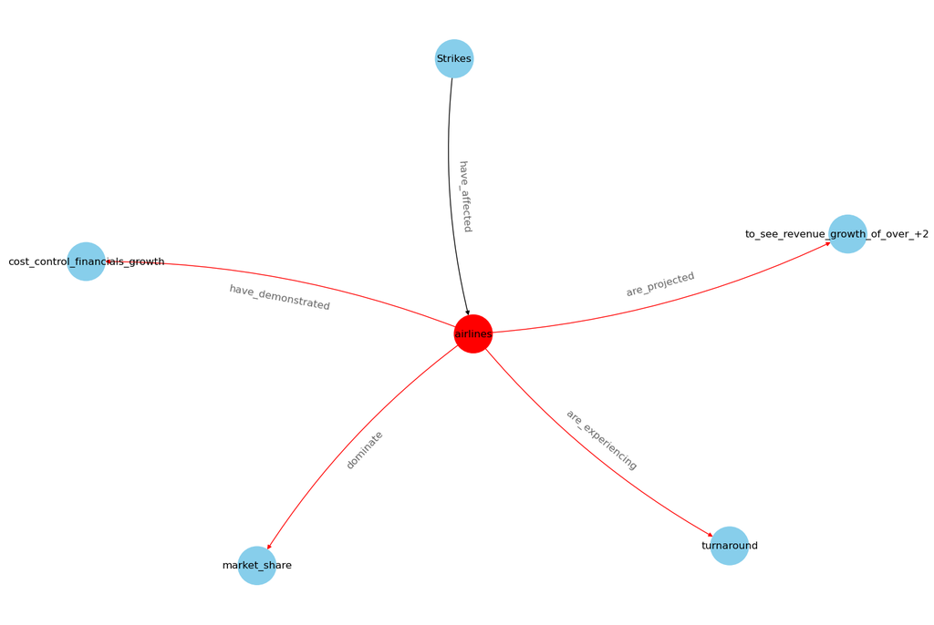

```python
## filter
f = "airlines"
tmp = dtf[(dtf["entity"]==f) | (dtf["object"]==f)]


## create small graph
G = nx.from_pandas_edgelist(tmp, source="entity", target="object",
                            edge_attr="relation",
                            create_using=nx.DiGraph())


## plot
plt.figure(figsize=(15,10))

pos = nx.nx_agraph.graphviz_layout(G, prog="neato")
node_color = ["red" if node==f else "skyblue" for node in G.nodes]
edge_color = ["red" if edge[0]==f else "black" for edge in G.edges]

nx.draw(G, pos=pos, with_labels=True, node_color=node_color,
        edge_color=edge_color, cmap=plt.cm.Dark2,
        node_size=2000, node_shape="o", connectionstyle='arc3,rad=0.1')

nx.draw_networkx_edge_labels(G, pos=pos, label_pos=0.5,
                        edge_labels=nx.get_edge_attributes(G,'relation'),
                        font_size=12, font_color='black', alpha=0.6)
plt.show()
```

## 2.通过chatgpt阅读文章直接提取所需的三元组

```python
# 首先读取文件
with open('triple lists.txt', 'r') as f:
    lines = f.readlines()

# 存储三元组的列表
triplets = []

# 分割每一行
for line in lines:
    words = line.split()

    # 假设主体和宾语都是一个单词，关系是剩下的所有单词
    subject = words[0]
    relation = " ".join(words[1:-1])
    object_ = words[-1]

    # 添加到三元组列表
    triplets.append([subject, relation, object_])

# 输出第一个三元组进行检查
print(triplets[0])
```

```
['United', 'Airlines posted record', 'earnings']
```

## 把已经形成的三元组塞入Neo4j图数据库中

```python
from neo4j import GraphDatabase

# 创建neo4j驱动
uri = "neo4j://localhost:7687"  # 替换为你的Neo4j数据库地址
username = "neo4j"  # 替换为你的用户名
password = "muli7419"  # 替换为你的密码
driver = GraphDatabase.driver(uri, auth=(username, password))
```

```python
def add_triplet_to_graph(driver, triplet):
    with driver.session() as session:
        session.run("MERGE (a:Entity {name: $subject}) "
                    "MERGE (b:Entity {name: $object}) "
                    "MERGE (a)-[:RELATION {type: $relation}]->(b)",
                    subject=triplet[0], relation=triplet[1], object=triplet[2])
```

```python
# 检查每个三元组的长度
for i, triplet in enumerate(triplets):
    if len(triplet) != 3:
        print(f"Error in triplet at index {i}: {triplet}")
```

```python
# 将每个三元组添加到图中
for triplet in triplets:
    add_triplet_to_graph(driver, triplet)

# 关闭驱动
driver.close()
```